# National travel-time accessibility to obstetrics-gynecology subspecialists, 2013-2023

Enhanced two-step floating catchment area (E2SFCA) analysis

Tyler M. Muffly, MD, and co-authors

Draft, internal co-author review

# Title Page

**Full title.** National travel-time accessibility to board-certified obstetrics-gynecology subspecialists in the contiguous United States, 2013-2023

**Short title (running head).** Access to board-certified obstetrics-gynecology subspecialists

**Précis.** Potential travel-time accessibility to board-certified obstetrics-gynecology subspecialists shows large, persistent rural and area-level racial disparities, worst in rural areas and in areas where American Indian or Alaska Native women live. *(30 words; O&G limit 25.)*

**Word count.** Abstract, 310 words (O&G limit 300); main text, approximately 3,268 words, above the *Obstetrics & Gynecology* Original Research target of roughly 2,500 to 3,000 words. Method and result detail has been moved to the Supplemental Digital Content (about 4,342 words across nine appendices); the residual excess is concentrated in the Discussion and can be trimmed further at the editor’s request.

**Data source.** Validated production run e2sfca_20260712_190734 (mass-conserving area-overlap allocator; 7 subspecialties × 11 years = 77 population-weighted national cells).

## Abstract

*Précis.* Potential travel-time accessibility to board-certified obstetrics-gynecology subspecialists shows large, persistent rural and area-level racial disparities, worst in rural areas and in areas where American Indian or Alaska Native women live.

**Objective.** To measure geographic access to the seven obstetrics-gynecology subspecialties across the contiguous United States, 2013 to 2023, and its disparities by rurality and by race and ethnicity.

**Methods.** We located every board-certified subspecialist active in each year and used modeled road-network travel times (30 to 180 minutes) to measure reachability for the 2020 female population (164,690,617 women; American Community Survey). Potential accessibility was estimated with an enhanced two-step floating catchment area model, which rewards shorter drives and accounts for competing demand. We compared access by urban versus rural location and by race and ethnicity, and described change from 2013 to 2022 (2023 provisional).

**Conclusion.** Access to obstetrics-gynecology subspecialists shows large, persistent rural and area-level racial disparities that narrowed little over the decade. Across-subspecialty differences identify standardized geographic reachability, not clinical adequacy, because every subspecialty was indexed to the same total-female denominator.

## Introduction

Access to advanced obstetric and gynecologic care depends not only on the size of the workforce but also on where clinicians practice relative to the populations they serve. The present study evaluates five subspecialties for which the American Board of Obstetrics and Gynecology (ABOG) administers subspecialty certification, complex family planning, gynecologic oncology, maternal-fetal medicine, reproductive endocrinology and infertility, and urogynecology and reconstructive pelvic surgery, and two areas with focused-practice designations, minimally invasive gynecologic surgery and pediatric and adolescent gynecology. Prior studies suggest substantial geographic concentration within individual fields: in 2020, 98.3% of gynecologic oncologists practiced in urban areas [1]; nearly 40% of reproductive-aged women lived in areas with limited or no nearby access to assisted reproductive technology services [2]; and a national study of Indian Health Service locations found a median drive time of 214 minutes to the nearest obstetric-gynecologic subspecialist [3]. No previous study, however, has compared potential travel-time accessibility across all seven fields using a common national framework.

Although geographic proximity is only one of the five dimensions of health care access [4,5], travel burden influences whether and when patients obtain care. Longer travel has been associated with less timely prenatal care [6], delays in abortion care [7], limited fertility treatment [2], and, in oncology, delayed diagnosis and worse outcomes [8], establishing travel time as a relevant barrier across obstetric and gynecologic care [9], while affordability, insurance, appointment availability, and preferences also shape realized access.

Prior geographic-access research has focused largely on single subspecialties and on straight-line or county-level distance. Desjardins and colleagues reported county-level disparities in access to gynecologic oncologists over 2001-2020 with no improvement for rural or American Indian or Alaska Native populations despite a doubling of the workforce [1]; Ackroyd and colleagues found approximately 91% of U.S. counties with no practicing gynecologic oncologist [10]. More broadly, nearly half of U.S. counties, roughly 20 million people, lack any obstetrician-gynecologist [11], and barely 1% of U.S. ZIP codes contain a urogynecologist, with the greatest burden reported in places where American Indian or Alaska Native women live [12]. These studies characterize access as county-level presence, a single travel-time threshold, or nearest-provider distance for one service at a time, none accounting for the population competing for a given subspecialist’s time. Less is known about how potential accessibility compares across the full set of OB/GYN subspecialties, how it has changed as the workforce entered, retired, and relocated, and how it is distributed by rurality and by race and ethnicity at a fine geographic scale.

We therefore estimated potential spatial accessibility to each of the seven specialty groups across the contiguous United States from 2013 to 2023, using an enhanced two-step floating catchment area model on road-network travel-time isochrones. We characterized national accessibility levels and temporal trends by subspecialty and quantified disparities by rurality and by race and ethnicity, with gynecologic oncology designated a priori as the detailed exemplar, both because timely oncologic access is prognostically important and to permit comparison with existing distance-based estimates [1].

## Materials and Methods

### Subspecialist cohort

For each calendar year, the analytic cohort comprised board-certified subspecialists who were clinically active in that year. Subspecialty was assigned from American Board of Obstetrics and Gynecology (ABOG) board-certification records, the certification standard used to define each subspecialty, rather than from self-reported specialty codes, under which all obstetrics-gynecology subspecialists are classified as generic obstetrics-gynecology.[^1] A physician was counted as clinically active in year *Y* when their estimated retirement year exceeded *Y* (strict inequality; retirement was estimated from a multi-source consensus of practice-activity signals, and certification dated entry to the subspecialty), and was placed at their practice location for that year, so each contributed to a subspecialty’s surface only while active. No physician-year showed multiple concurrent locations, so no supply was double-counted (eMethods). Physicians were included only if their practice address geocoded to a contiguous-U.S. location. Each specialty group’s supply is therefore a geocoded, contiguous-U.S., clinically-active count, smaller than a board-certification headcount, which counts all certificants regardless of clinical activity, geocoding, or location. In 2020, 4,322 subspecialists were active across the seven specialty groups (Table 1), and the panel comprises 77 specialty-year cells (7 groups × 11 years).

### Population, denominators, and geographic units

The demand denominator was the total female population by census tract (ACS table B01001), applied identically to all seven subspecialties to yield a standardized index; because the subspecialties serve different age ranges (for example, pediatric and adolescent gynecology serves children and adolescents, whereas urogynecology serves a predominantly older population), across-subspecialty rate comparisons reflect workforce size and clinical scope in addition to access (Discussion). For race and ethnicity, non-Hispanic White (ACS table B01001H) and Hispanic-origin (any race; B01001I) women were analyzed alongside race-alone groups (Black, Asian, American Indian or Alaska Native, and Native Hawaiian or Other Pacific Islander; B01001B-E); because race-alone counts can include persons of Hispanic origin, these are separately defined groups, not a mutually exclusive partition. Rurality used U.S. Department of Agriculture Rural-Urban Commuting Area (RUCA) codes [16], with primary codes 1-3 metropolitan and 4-10 rural. Census tract vintage changed between 2019 and 2020 (2013-2019 on 2010-vintage tracts, 2020-2023 on 2020-vintage, each with contemporaneous ACS estimates); a prespecified seam analysis showed negligible effects on the national estimates, and a subgroup seam test holding the 2020 cohort fixed found the vintage-induced shift small for every group (median 0.05 percentage point in the zero-access share, at most 0.5 for rural areas or areas where American Indian or Alaska Native women lived and 1.3 overall; mean-access shift ≤0.018 per 100,000), so the subgroup trends are not vintage artifacts (Discussion; eMethods S3). Alaska’s exclusion is relevant to the American Indian or Alaska Native findings (Discussion). The 2020 analysis represented 164,690,617 women.

### Enhanced two-step floating catchment area accessibility

We measured access with the enhanced two-step floating catchment area (E2SFCA) method [18,19], a standard way to estimate how reachable a service is once both travel distance and competition are taken into account. It combines two questions. First, for each subspecialist, how many women live within driving range, and therefore compete for that physician’s time? Second, for each neighborhood, how many subspecialists lie within driving range, after each is discounted by the demand he or she already serves? Providers a woman can reach quickly count more than ones hours away. The result is a single number for every location, the subspecialists effectively available per 100,000 women, scaled so the national average equals 1.00 [20].

One feature matters for interpretation: the national average is mathematically just the total subspecialists divided by the total population, so we report it only as a standardized measure of workforce size, not of geographic access. The access signal lies in how the index is *distributed*, whether rural and urban women and different racial and ethnic groups can reach a subspecialist and how much of the population lies outside any subspecialist’s reach; those distributional measures are our primary outcomes. The travel-time weights, formulas, and sensitivity tests are in eMethods S4.

### Mass-conserving demand allocation

To line up the physician catchments with where women live, we spread each census tract’s female population across a fine 500-m national grid in proportion to land area, so every tract’s population total was preserved (0.00% lost, versus 1.06% when a tract is collapsed to a single center point); a coarser 1,000-m grid gave nearly identical results. This assumes population is spread evenly within a tract, an approximation that is weakest in large rural and tribal tracts (eMethods S2).

### Temporal comparison

The 2013-2023 comparison surfaces were computed on a single common grid and denominator (2020 vintage; ACS 2020) so the difference reflects only the change in the active cohort (eMethods S3).

### Statistical analysis

National accessibility was summarized as the population-weighted mean; because the physician catchments are deterministic and tracts were treated as independent, ACS-only intervals are near-zero-width and are reported as ACS sampling intervals, not comprehensive confidence intervals. We separately quantified a deterministic model-specification envelope for the main 2020 disparity ratios across the sensitivity specifications. Temporal change was summarized by ordinary least-squares slopes with Newey-West HAC P values, excluding the most recent (right-censored) year; stratified trend analyses are exploratory. The uncertainty model, zero-access estimators, trend specification, and robustness analyses are detailed in eMethods S1. Analyses used R version 4.5.1.

## Results

### Subspecialist workforce and study population

We modeled potential spatial accessibility to board-certified obstetrics-gynecology subspecialists active in each year from 2013 through 2023, for the 164,690,617 women represented by the 2020 American Community Survey [13]. In 2020, the active workforce comprised 1,244 maternal-fetal medicine (MFM), 890 gynecologic oncology (GO), 848 reproductive endocrinology and infertility (REI), 783 urogynecology and reconstructive pelvic surgery (URPS), 372 minimally invasive gynecologic surgery (MIGS), 113 pediatric and adolescent gynecology (PAG), and 72 complex family planning (CFP) physicians (Table 1).

Table 1. Active Workforce and Standardized Supply per Population by Obstetrics-Gynecology Subspecialty, 2020

| Subspecialty | Active, non-federal, patient care physicians, 2020 | Supply per 100,000 women (all ages), 2020 | Change, 2013-2022 |
| --- | --- | --- | --- |
| Maternal-fetal medicine | 1,244 | 0.755 | -30.2% |
| Gynecologic oncology | 890 | 0.540 | +13.3% |
| Reproductive endocrinology and infertility | 848 | 0.515 | -7.0% |
| Urogynecology and reconstructive pelvic surgery | 783 | 0.476 | +10.4% |
| Minimally invasive gynecologic surgery | 372 | 0.226 | +50.1% |
| Pediatric and adolescent gynecology | 113 | 0.069 | -0.5% |
| Complex family planning | 72 | 0.044 | +28.4% |

Counts are active, non-federal, patient care physicians in 2020, defined here as board-certified subspecialists clinically active that year and geocoded to a contiguous-U.S. practice location. The supply-per-population column is the national population-weighted mean of the enhanced two-step floating catchment area surface, which by a property of the method equals subspecialist supply per 100,000 women (Methods); it is a standardized workforce-distribution index, not a spatial-accessibility measure, and its ranking is the workforce-size ranking. Spatial distribution and disparities are reported in Tables 2-3 and Figures 3-6. Change is the descriptive relative change from 2013 to 2022; 2023 is right-censored and reported provisionally. Trend inference is given in Appendix Table S1. AIAN, American Indian or Alaska Native; CFP, complex family planning; GO, gynecologic oncology; MFM, maternal-fetal medicine; MIGS, minimally invasive gynecologic surgery; PAG, pediatric and adolescent gynecology; REI, reproductive endocrinology and infertility; URPS, urogynecology and reconstructive pelvic surgery.

### Spatial distribution and inequality of access

Because the national mean carries no spatial information (Methods), we describe the *geographic distribution* of access. In 2020, potential accessibility concentrated in metropolitan areas of the eastern and midwestern United States, with large regions of the Mountain West and Great Plains outside any subspecialist’s catchment; the scarcest fields, complex family planning and pediatric and adolescent gynecology, showed extensive zero-access areas across most land outside major metros (Figure 1).

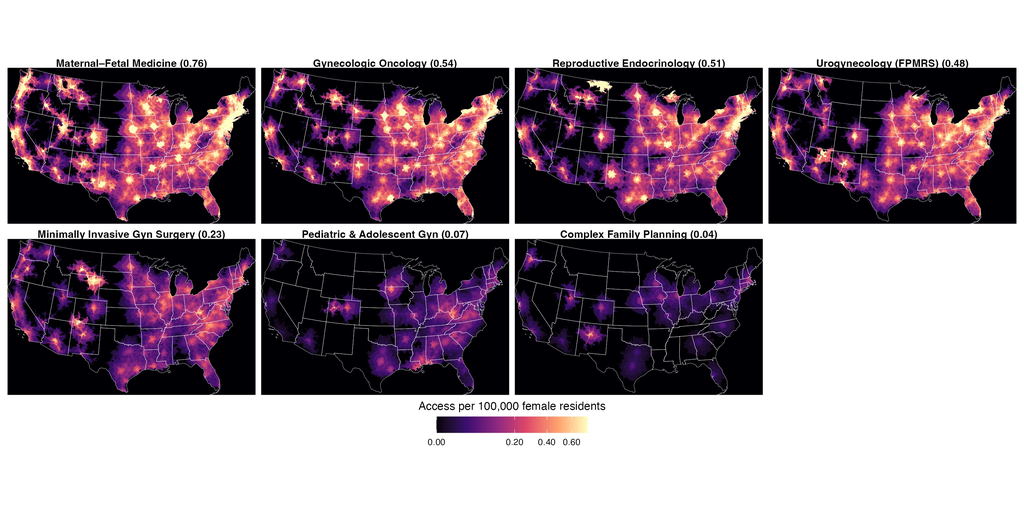

**Figure 1.** Potential spatial accessibility to each obstetrics-gynecology subspecialty, 2020, per 100,000 women, estimated with an enhanced two-step floating catchment area model on 30-, 60-, 120-, and 180-minute travel-time isochrones. Brighter shading indicates greater potential accessibility; black indicates no modeled access (a desert). One panel per subspecialty on a shared square-root color scale (capped at the 98th percentile); the number in each label is the national population-weighted mean. Mass-conserving 500-m demand grid aggregated to a 1,000-m display surface; contiguous United States.

Table 2. Spatial Distribution and Inequality of Potential Accessibility by Subspecialty, 2020

| Subspecialty | % outside 60 min | % outside 120 min | % outside 180 min | Gini |
| --- | --- | --- | --- | --- |
| Gynecologic oncology | 19.3 | 4.0 | 1.0 | 0.39 |
| Maternal-fetal medicine | 19.2 | 5.7 | 1.9 | 0.30 |
| Reproductive endocrinology and infertility | 23.1 | 7.1 | 2.2 | 0.39 |
| Urogynecology and reconstructive pelvic surgery | 17.8 | 4.9 | 2.1 | 0.29 |
| Minimally invasive gynecologic surgery | 25.6 | 9.0 | 3.3 | 0.35 |
| Pediatric and adolescent gynecology | 43.9 | 20.3 | 9.7 | 0.50 |
| Complex family planning | 59.8 | 37.2 | 21.7 | 0.64 |

“% outside t min” is the share of women with no subspecialist reachable within a t-minute drive (population-weighted, road-network travel time). Gini is the population-weighted Gini index of the accessibility surface (0 = perfectly even; higher = more spatially concentrated). These are spatial-distribution measures and, unlike the standardized supply index in Table 1, depend on provider geography. Computed on a 1-km demand grid. AIAN, American Indian or Alaska Native; CFP, complex family planning; GO, gynecologic oncology; MFM, maternal-fetal medicine; MIGS, minimally invasive gynecologic surgery; PAG, pediatric and adolescent gynecology; REI, reproductive endocrinology and infertility; URPS, urogynecology and reconstructive pelvic surgery.

The standardized supply index (Table 1) was highest for maternal-fetal medicine and lowest for complex family planning (Figure 2A); because it equals workforce supply per population (Methods), it reflects workforce size and clinical scope, not spatial access, and is not comparable across subspecialties.

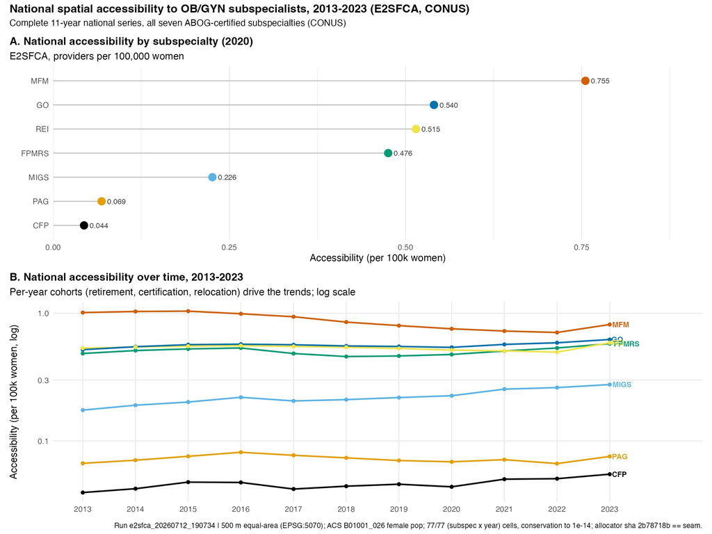

**Figure 2.** National potential accessibility to OB/GYN subspecialists, 2013-2023 (E2SFCA on travel-time isochrones). (A) Population-weighted accessibility by subspecialty, 2020. (B) By subspecialty, 2013-2023 (log scale). Cell-level population-weighted; per 100,000 women.

### Disparities by rurality

For gynecologic oncology in 2020, population-weighted accessibility was 0.60 per 100,000 women in metropolitan areas versus 0.26 in rural areas, a metropolitan-to-rural ratio of 2.27 (Figure 3A; ACS uncertainty intervals for all estimates appear in Table 3). At the extreme of no access, 4.1% of rural women lived in a tract with zero mean modeled access to a gynecologic oncologist, versus 0.6% of metropolitan women, roughly sixfold higher.

### Disparities by race and ethnicity

Areas where American Indian or Alaska Native women lived had the lowest gynecologic oncology accessibility (0.379 per 100,000) and the highest share of group population in census tracts with zero mean modeled access (9.4%); the zero-access share was 8.2 percentage points higher than for areas where non-Hispanic White women lived (ACS uncertainty interval excluding zero). Areas where Asian women lived had the highest modeled accessibility (Figure 3B).

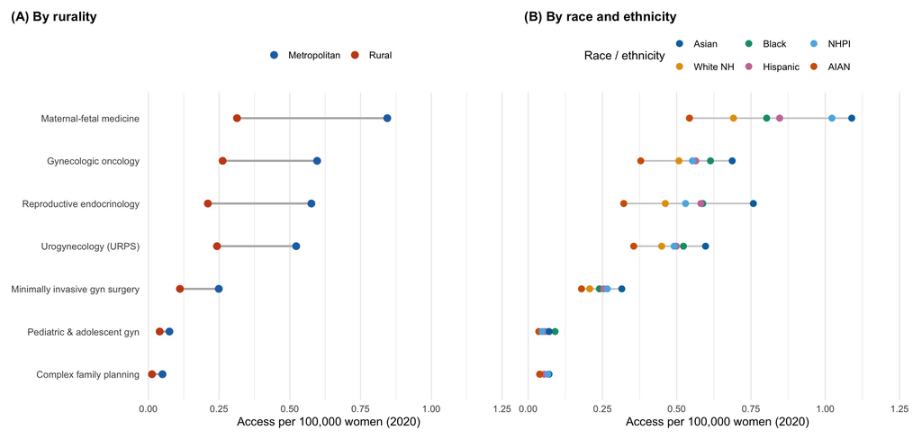

**Figure 3.** Population-weighted 2020 accessibility to the seven OB/GYN subspecialties by (A) rurality and (B) race and ethnicity, per 100,000 women; subspecialties ordered by national mean. In (A) each line joins the rural and metropolitan means; in (B) each point is one group, spanning the lowest to the highest. Rurality is USDA RUCA 2020 (metropolitan = codes 1 to 3); race-alone groups are not mutually exclusive with the non-Hispanic White and Hispanic groups. AIAN, American Indian or Alaska Native; NHPI, Native Hawaiian or Other Pacific Islander; URPS, urogynecology and reconstructive pelvic surgery.

### Disparities across all subspecialties

The rurality and area-level race/ethnicity disparities held across all seven specialty groups (Figure 3), with rural areas and areas where American Indian or Alaska Native women lived lowest in every one; per-subspecialty estimates are in eResults S5.

### Persistence of disparities over time

The rural and area-level racial disparities persisted with little narrowing across 2013-2023; the year-by-year detail is in eResults S6.

### Access deserts across subspecialties

The share of women outside any modeled catchment (“access deserts”) varied widely by subspecialty; per-subspecialty values are in eResults S7.

## Discussion

In this national analysis of potential spatial accessibility to the seven ABOG-certified obstetric-gynecologic subspecialties, accessibility concentrated in metropolitan areas and was lowest for rural areas and for areas where American Indian or Alaska Native women lived, changing little across the study period. The subspecialties differed markedly in standardized geographic reachability and temporal trajectories, but those cross-subspecialty differences should not be read as differences in clinical adequacy because the denominator was the same total female population for every field.

Our findings extend prior single-subspecialty and county-level work. For gynecologic oncology, our results refine the county-level model of Desjardins and colleagues, who found 95.2% of counties (roughly 54.7 million at-risk women) with no gynecologic oncologist and no improvement over two decades for American Indian or Alaska Native women beyond 100 miles (25.6% to 23.7%; P=.866) [1]. Our smaller board-certified cohort makes counts not directly comparable, but our travel-time, tract-level surface corroborates the same inequities across all seven groups. A state-level E2SFCA analysis similarly found 18.4% of Georgia tracts with zero access [21], the logic behind our stratified synthesis (Figure 4).

A provider-referenced metric reinforces this for urogynecology: the extra travel to the nearest urogynecologist beyond the nearest general obstetrician-gynecologist [22]. Women 65 or older in the median county faced roughly 29 additional miles, and 17% faced more than 30, evidence that subspecialty maldistribution, not an absence of gynecologic care, drives the rural gap.

Our other-subspecialty findings are likewise consistent with the literature: the extensive reproductive endocrinology and infertility deserts echo estimates that roughly 29% of reproductive-aged women lack a nearby assisted reproductive technology clinic, with documented racial and ethnic disparities [23], and an oncofertility analysis found the share beyond a two-hour drive nearly doubled from general to subspecialized care (3.4% to 5.7%) [24]. Such disparities are multifactorial, extending beyond structural access [25].

This persistence mirrors access gradients across many specialized services, from cardiac rehabilitation and transplantation to cancer, mental health, and rehabilitation care, where rural and American Indian or Alaska Native populations are consistently farther from care [26-34]; the most comparable, a national E2SFCA analysis of six dental specialties, reproduced our patterns, with more than 98% of specialists urban and rural people driving roughly three times as far [35]. Because subspecialists cluster in metropolitan academic and referral centers, many rural and American Indian or Alaska Native areas lie beyond even a 180-minute drive of any, so workforce growth alone need not reach them; indeed the workforce grew while their access held nearly constant. Because the denominator is total population rather than disease or procedure demand, these estimates locate where the geographic component of access is most deficient, not where clinical need is greatest. Narrowing the gaps therefore likely requires strategies that decouple access from physician relocation, hub-and-spoke models, telehealth, knowledge-sharing networks such as Project ECHO [36], placement incentives, and visiting-specialist clinics, each warranting evaluation rather than presumed benefit.

Potential accessibility is not a surrogate for realized use: of the five dimensions of access, the model captures only availability and geographic accessibility [4,5], not affordability, accommodation, or acceptability. Populations with high modeled proximity can still fare poorly, facing systemic racism, insurance and scheduling barriers, and higher disease burden [37]. The metropolitan concentration mirrors the race-by-rurality intersection reported for emergency surgery [38] and mammography [39]; because racial outcome disparities attenuate after adjustment for insurance, income, and education [40], a geographic difference becomes an inequity when patterned by unequally distributed social factors [41]. Modeled proximity is thus necessary but insufficient for equitable care.

Strengths include a near-census of board-certified subspecialists rather than a sample; road-network rather than straight-line travel times; a mass-conserving demand allocation representing the full female population [42]; year-specific cohorts reflecting workforce entry, exit, and relocation; and fully reproducible, canonical-source computation. Unlike nearest-provider travel time or provider ratios, the floating-catchment design jointly incorporates provider availability, competing demand, and travel impedance, flagging low-access areas those simpler measures miss [43].

Several limitations temper interpretation. The common total-female-population denominator makes across-subspecialty comparisons reflect workforce size and clinical scope as well as access, so these standardized indices should not be read as direct measures of clinical adequacy; the index measures potential rather than realized access and omits practice capacity, appointment availability, insurance, and patient travel behavior; the reported intervals capture only ACS sampling error; the zero-access metric is tract-level; race-alone and Hispanic-origin groups are not mutually exclusive; the race/ethnicity contrasts are ecological descriptions of the areas where groups live, not individual-level causal effects; and Alaska’s exclusion limits generalizability to Alaska Native communities with distinct transportation barriers. These points, with international-border edge effects, the uniform-within-tract density assumption, and directions for patient-flow calibration, are detailed in eDiscussion S9.

## Conclusion

Across the contiguous United States, potential accessibility to board-certified obstetric and gynecologic subspecialists was persistently lower in rural areas and in areas where American Indian or Alaska Native women lived, and narrowed little over more than a decade. As a measure of where specialized care is potentially reachable, not of realized or clinically sufficient access, these findings identify the populations and regions that may benefit most from regionalized care, outreach, telehealth, and targeted workforce strategies.

## Supplemental Digital Content

## eMethods S1: Statistical analysis

National accessibility was summarized as the population-weighted mean at the raster-cell level. We report two quantified uncertainty layers. First, ACS uncertainty intervals reflect sampling error in the population weights: because the physician catchments and cell-level accessibility values are deterministic (a near-census of active physicians on fixed isochrones), we propagated the ACS margins of error by Monte-Carlo simulation (2,000 draws; each tract’s female population drawn from a Normal distribution with SD = margin of error ÷ 1.645) and summarized each estimate by the 2.5th and 97.5th percentiles. Draws were not truncated at zero: because they enter only aggregate weighted sums (where the expectation equals the sum of the tract estimates), clamping would inject spurious positive weight into the many zero-population tracts and bias sparse groups (for example, American Indian or Alaska Native) upward. Tracts were treated as independent, so the variance of an aggregate is the sum of tract variances; this does not use the ACS covariance structure or replicate weights, and because errors average out across the tens of thousands of tracts, the intervals for pooled quantities, especially aggregate ratios such as the metropolitan-to-rural ratio, collapse to implausibly narrow ranges. Such intervals should be read as ACS-only intervals rather than comprehensive confidence intervals; we accordingly report a point estimate alone where the interval is narrower than the reported precision. Second, we report a deterministic model-specification envelope across the prespecified 2020 sensitivity specifications (Appendix Tables S2-S2b), spanning distance-decay weights, the 180-minute catchment, grid resolution, Gaussian-derived zonal weights, and an M2SFCA maldistribution penalty. This envelope is not a probability interval, but it quantifies how much the main rurality and AIAN-vs-White contrasts move under plausible modeling choices. It still does not incorporate stochastic uncertainty from physician ascertainment, clinical-activity classification, geocoding, multiple practice locations, practice capacity, or road-network travel-time modeling. Rurality- and race/ethnicity-stratified estimates were computed at the tract level (required to attach RUCA rurality and race-specific denominators) and reconcile with the cell-level national summary to within 0.001 per 100,000 women. The zero-access metric (“% zero”) is the share of a group’s population living in census tracts whose mean modeled access is zero. As a sensitivity comparison, we also computed a cell-level estimator for 2020, the area-weighted share of each tract lying in grid cells with zero access, weighted by the tract’s group population, which was stable between the 500-m and 1,000-m grids (agreement within 0.1 percentage point for the subspecialties checked) and gave higher zero-access shares than the tract-mean definition (Appendix Table S3). Because both estimators rest on the same area-weighted (uniform within-tract density) allocation, this difference reflects the choice of definition, not independent evidence that either value is more accurate; a dasymetric or block-level allocation would be required to establish that (Discussion). A subspecialist was considered reachable if the practice location fell within the 180-minute maximum travel-time catchment. Temporal change was summarized by ordinary least-squares slopes of the annual estimate on calendar year over 2013-2022. Because successive ACS 5-year estimates overlap and provider cohorts are serially correlated, we also computed Newey-West heteroskedasticity- and autocorrelation-consistent (HAC) P values, with the lag prespecified at 4 to reflect the overlap of the 5-year ACS window (Appendix Table S1); because only 10 annual estimates were available, these trend tests are imprecise and are interpreted descriptively. The stratified trend analyses across the seven specialty groups and multiple groups are exploratory: we prespecified no primary comparison and applied no multiple-comparisons correction, and we therefore emphasize the direction and magnitude of change over statistical significance. The most recent year (2023) was excluded from trend estimation and is reported as a provisional observation because its workforce panel is subject to right-censoring. To assess robustness to modeling choices, we recomputed the 2020 accessibility surface for every subspecialty under the alternative specifications summarized in Appendix Table S2, and compared the national ranking and the rurality and race contrasts with the base specification. Analyses used R version 4.5.1.

## eMethods S2: Mass-conserving demand allocation

Demand was allocated from census tracts to a 500-m equal-area analysis grid (EPSG:5070) by polygon-cell area overlap, conserving every tract’s population (mass-conserving area-weighted allocation). This preserved each tract’s modeled population total (0.00% loss) versus a 1.06% loss under conventional centroid-based allocation; per-year national totals were conserved to within 10⁻⁶. Conserving population prevents the loss that centroid allocation incurs and reduces the display-scale aggregation that coarser zone centroids impose [44]; it does not, however, improve the underlying spatial precision, because population is distributed by land-area overlap and the method therefore assumes uniform population density within each tract. This assumption is least tenable in large rural and tribal tracts, where women occupy a small fraction of the land area, so the 500-m surface can appear more spatially precise than the tract-level input justifies (see Limitations). The 500-m and 1,000-m surfaces nonetheless gave near-identical results (Appendix Table S2).

## eMethods S3: Temporal comparison, 2013-2023

National accessibility was computed for every subspecialty-year cell. To visualize decade-scale change while isolating the cohort effect, the 2013 and 2023 accessibility surfaces for each subspecialty were computed on a single common grid and demand denominator (2020 tract vintage; ACS 2020), so the difference reflects only the change in the active physician cohort.

*Appendix 1. Accessibility change by subspecialty, 2013-2023 (to be posted online as Supplemental Digital Content).*

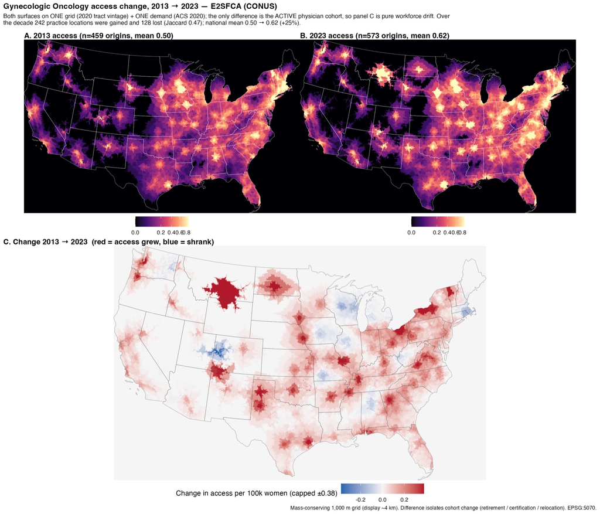

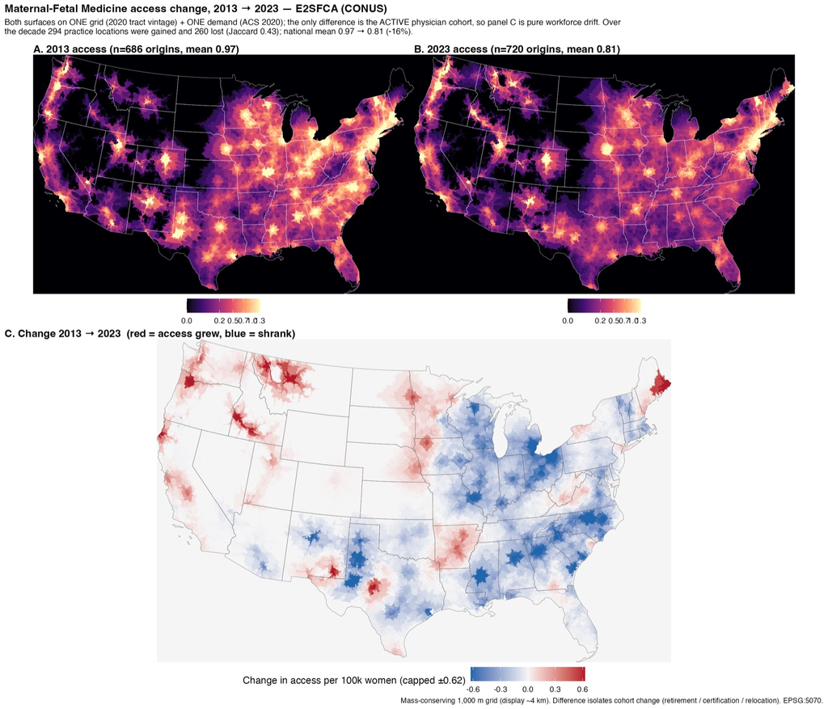

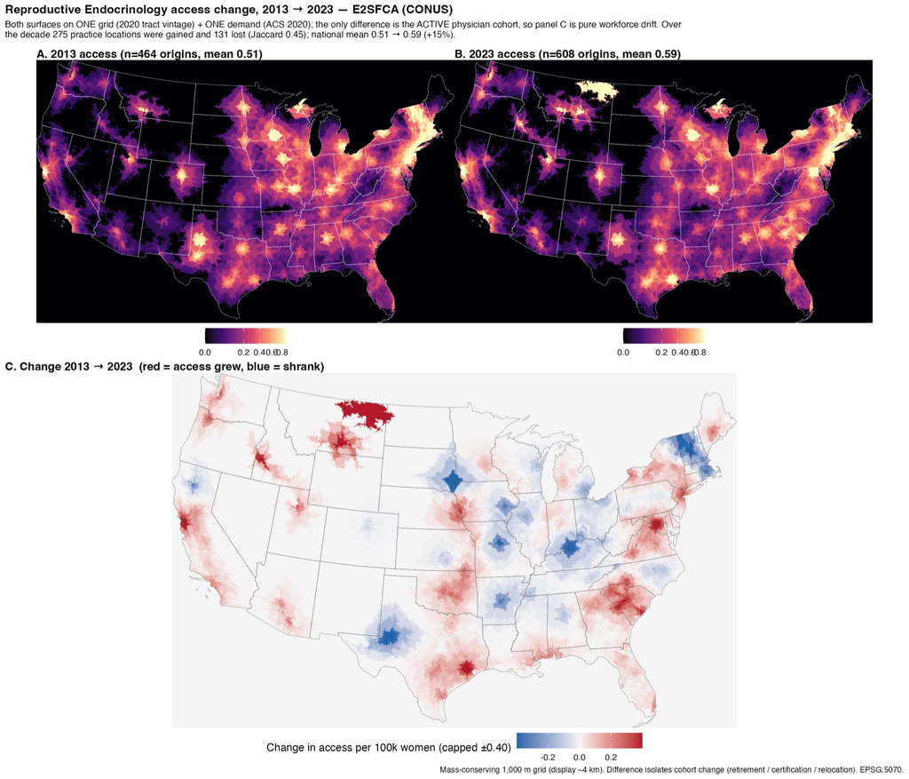

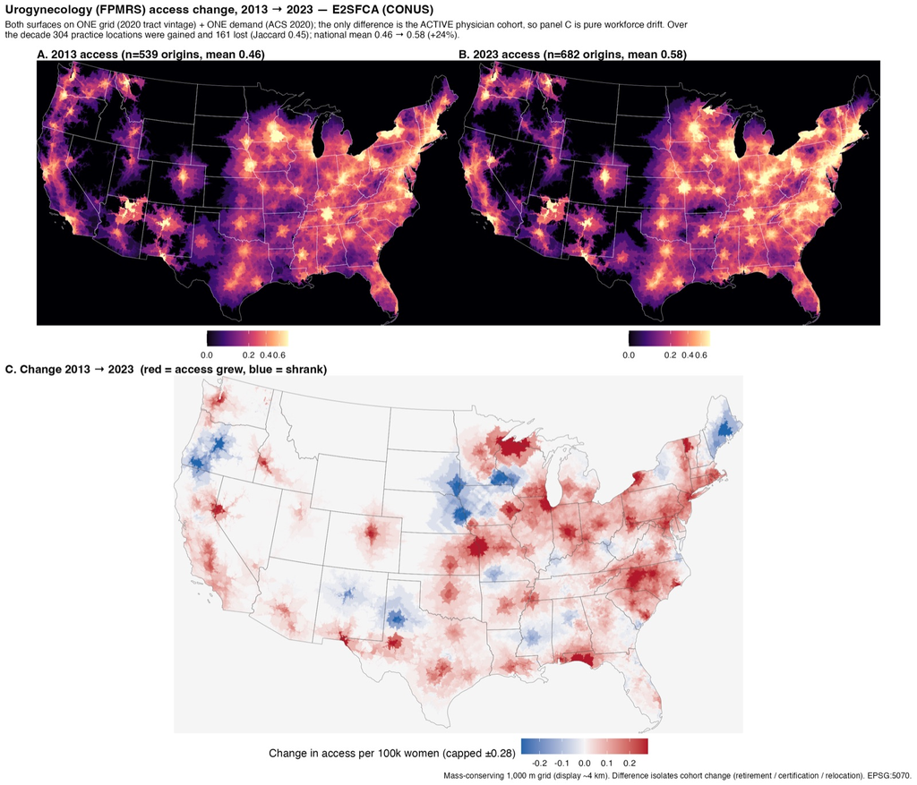

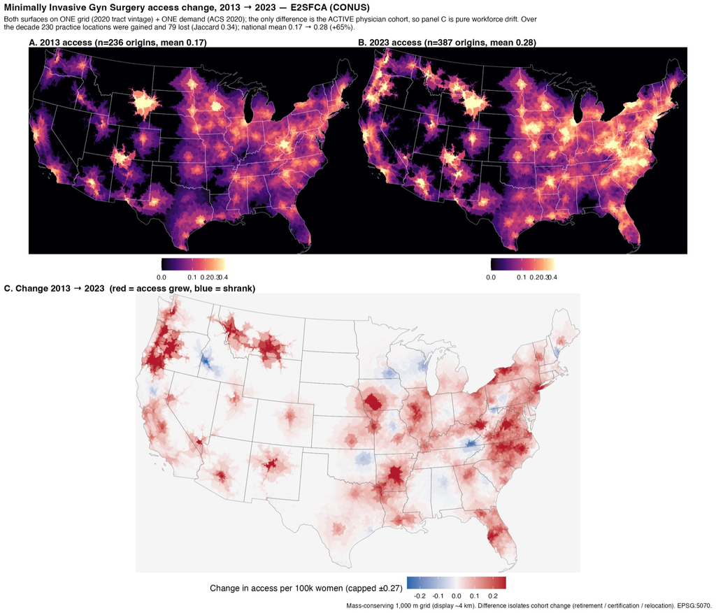

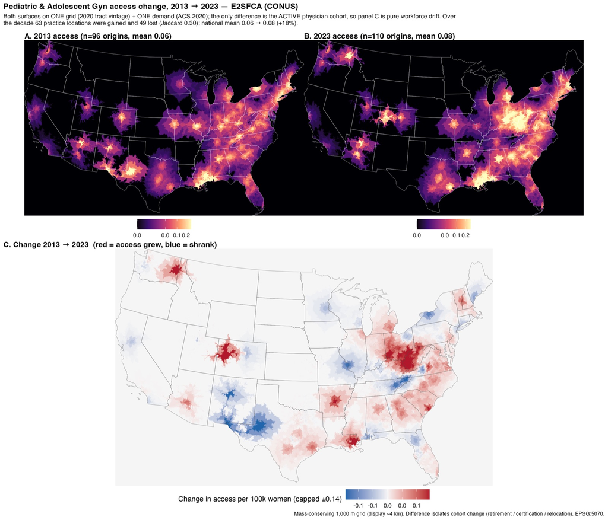

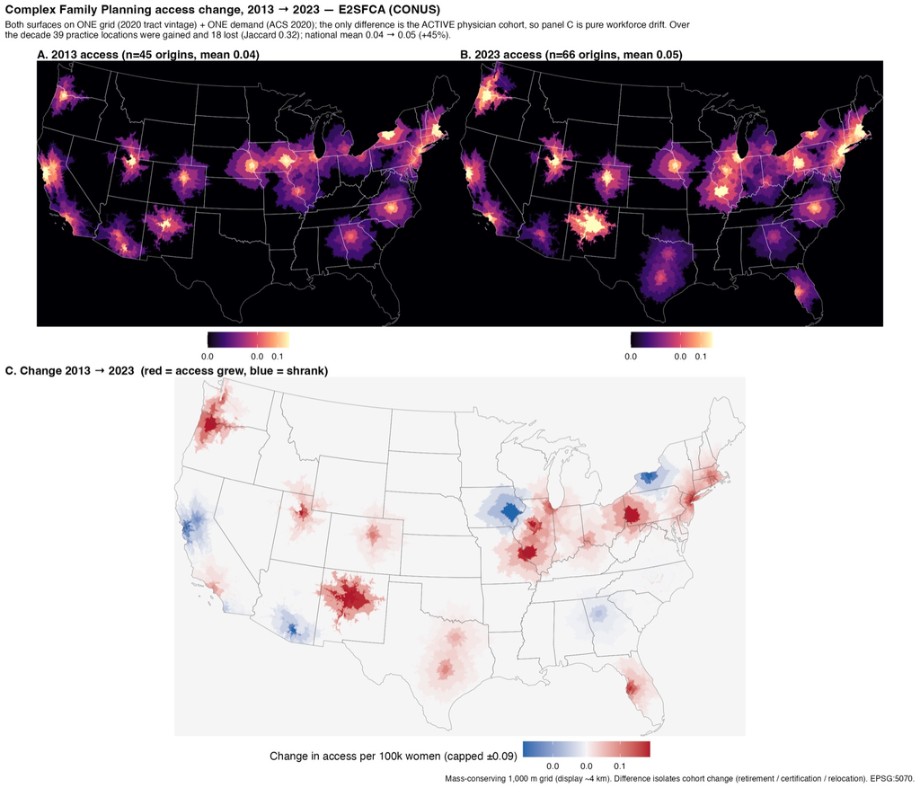

**Figures S1-S7.** Access change 2013 → 2023 for gynecologic oncology, maternal-fetal medicine, reproductive endocrinology and infertility, urogynecology and reconstructive pelvic surgery (URPS), minimally invasive gynecologic surgery, pediatric and adolescent gynecology, and complex family planning. Both years computed on one 2020 grid and demand so panel C isolates workforce change.

Appendix Table S1. Trends in the Zero-Access Share by Subspecialty, 2013-2022

| Subspecialty | Group | Slope (pp/y) | P, OLS | P, HAC |
| --- | --- | --- | --- | --- |
| Gynecologic oncology | Rural | -0.058 | .085 | .008 |
| Gynecologic oncology | AIAN | -0.202 | <.001 | <.001 |
| Maternal-fetal medicine | Rural | -0.075 | .028 | .004 |
| Maternal-fetal medicine | AIAN | -0.201 | <.001 | <.001 |
| Reproductive endocrinology and infertility | Rural | +0.012 | .667 | .688 |
| Reproductive endocrinology and infertility | AIAN | -0.021 | .608 | .658 |
| Urogynecology and reconstructive pelvic surgery | Rural | +0.010 | .842 | .833 |
| Urogynecology and reconstructive pelvic surgery | AIAN | -0.031 | .491 | .357 |
| Minimally invasive gynecologic surgery | Rural | -0.017 | .898 | .895 |
| Minimally invasive gynecologic surgery | AIAN | +0.034 | .915 | .914 |
| Pediatric and adolescent gynecology | Rural | +0.172 | .609 | .577 |
| Pediatric and adolescent gynecology | AIAN | +1.158 | .015 | .002 |
| Complex family planning | Rural | -2.057 | .004 | <.001 |
| Complex family planning | AIAN | -1.528 | .002 | <.001 |

Slope is the ordinary least-squares change per year in the percentage of a group’s population living in census tracts with zero mean modeled access, over 2013-2022 (10 annual estimates; 2023 excluded as right-censored). P, OLS is the naive ordinary least-squares P value; P, HAC is a Newey-West heteroskedasticity- and autocorrelation-consistent P value with the lag prespecified at 4 to reflect the overlap of American Community Survey 5-year estimates. With only 10 observations these trend tests are imprecise and are interpreted descriptively. HAC, heteroskedasticity- and autocorrelation-consistent; OLS, ordinary least squares; AIAN, American Indian or Alaska Native; CFP, complex family planning; GO, gynecologic oncology; MFM, maternal-fetal medicine; MIGS, minimally invasive gynecologic surgery; PAG, pediatric and adolescent gynecology; REI, reproductive endocrinology and infertility; URPS, urogynecology and reconstructive pelvic surgery.

*Appendix 2. Sensitivity of the 2020 findings to modeling assumptions.*

The 2020 accessibility surface for each subspecialty was recomputed under alternative distance-decay weights (sharper and slower falloff than the base weights, and a true Gaussian with sigma = 60 min), an M2SFCA maldistribution penalty, a reduced catchment that dropped the 180-minute band, and the production 500-m grid (the sensitivity was computed on a 1,000-m reference grid for efficiency; the 500-m specification reproduces the resolution that generated the production national values). The national population-weighted mean and its induced subspecialty ranking were identical across every specification (Spearman ρ = 1.00); this is *not* evidence of spatial robustness but a direct consequence of the conservation property (Methods), the national mean equals supply divided by population and does not depend on the decay weights, catchment bands, or grid resolution. The meaningful sensitivity is therefore in the *spatial* quantities. Rural women had lower accessibility than metropolitan women for all 7 subspecialties under every specification. Areas where American Indian or Alaska Native women lived had lower accessibility than areas where non-Hispanic White women lived for all 7 subspecialties under the base, sharper-decay, true-Gaussian, dropped-band, and production-resolution specifications, and for 6 of 7 under the slowest decay and the M2SFCA maldistribution penalty (complex family planning, already near parity, crossed to a slight advantage). Magnitudes did move, and Table S2 reports them: the median rural:metro accessibility ratio was 0.44 at the reference specification and ranged from 0.22 (M2SFCA maldistribution penalty; deeper rural gap) to 0.56 (slower distance decay; shallower gap), while the median AIAN:White ratio moved only within 0.77-0.83 (reference 0.78) and stayed below 1.00 in every specification. The production-resolution (500-m) grid reproduced the reference results almost exactly. The per-subspecialty model-specification envelope (Appendix Table S2b) ranged from 0.11 to 0.68 for the rural:metro ratio and from 0.51 to 1.06 for the AIAN:White ratio; no rural:metro contrast crossed 1.00, and the AIAN:White contrast crossed 1.00 only in near-parity specifications. This insensitivity of direction to the distance-decay weights is consistent with prior enhanced two-step floating catchment area analyses, including studies of mental health and of maternal-health services, in which access estimates were likewise robust to varying the decay parameter [34,45].

Appendix Table S2. Sensitivity of 2020 Findings to Modeling Assumptions (Seven Specialty Groups)

| Specification | Rank ρ | Rural:metro ratio (median) | AIAN:White ratio (median) | Rural < metro | AIAN < White |
| --- | --- | --- | --- | --- | --- |
| Sharper distance decay | 1.00 | 0.31 | 0.78 | 7/7 | 7/7 |
| Slower distance decay | 1.00 | 0.56 | 0.81 | 7/7 | 6/7 |
| Drop 180-min band (30/60/120) | 1.00 | 0.40 | 0.78 | 7/7 | 7/7 |
| Production resolution (500-m grid) | 1.00 | 0.44 | 0.78 | 7/7 | 7/7 |
| Gaussian distance decay (sigma = 60 min) | 1.00 | 0.37 | 0.77 | 7/7 | 7/7 |
| M2SFCA maldistribution penalty | 1.00 | 0.22 | 0.83 | 7/7 | 6/7 |

Each 2020 accessibility surface was recomputed under the listed specification and compared with the reference specification (empirically selected band weights 1/0.68/0.22/0.09 for the 30/60/120/180-minute bands). The sensitivity was computed on a 1,000-m reference grid for efficiency; the production/authoritative national values use a 500-m grid (Methods), reproduced by the ‘Production resolution’ row. Rank ρ is the Spearman correlation of the seven specialty groups’ national population-weighted mean accessibility with the reference ranking (reference median rural:metro ratio 0.44, AIAN:White ratio 0.78). The ratio columns are the median across the seven specialty groups; a ratio below 1 means the lower-access stratum had lower accessibility. “Rural < metro” and “AIAN < White” count the subspecialties in which that held. AIAN, American Indian or Alaska Native; CFP, complex family planning; GO, gynecologic oncology; MFM, maternal-fetal medicine; MIGS, minimally invasive gynecologic surgery; PAG, pediatric and adolescent gynecology; REI, reproductive endocrinology and infertility; URPS, urogynecology and reconstructive pelvic surgery.

Appendix Table S2b. Per-Subspecialty Model-Specification Uncertainty Envelope for 2020 Disparity Ratios

[output not shown]

Envelope is the minimum and maximum ratio across the seven deterministic model specifications in Appendix Table S2, including the reference specification. It quantifies sensitivity to distance-decay weights, catchment band inclusion, grid resolution, Gaussian-derived zonal weights, and M2SFCA penalty. It is not a confidence interval and does not include uncertainty from physician ascertainment, clinical-activity classification, geocoding, multiple practice locations, practice capacity, or road-network travel-time modeling. A direction reversal means the lower-access stratum had a ratio of at least 1.00 under that many specifications. AIAN, American Indian or Alaska Native; CFP, complex family planning; GO, gynecologic oncology; MFM, maternal-fetal medicine; MIGS, minimally invasive gynecologic surgery; PAG, pediatric and adolescent gynecology; REI, reproductive endocrinology and infertility; URPS, urogynecology and reconstructive pelvic surgery.

*Appendix 3. Cell-level versus tract-level zero-access, 2020.*

Appendix Table S3. Cell-Level vs Tract-Level Zero-Access Share (%), 2020 (cell / tract)

[output not shown]

Each cell shows the cell-level zero-access share / the tract-level share (%). Cell-level is the group-population-weighted mean of each tract’s area fraction in 500-m grid cells with zero modeled access; tract-level is the share in tracts whose mean access is zero. Both estimators assume uniform within-tract density, so the higher cell-level values reflect the definition, not evidence that either is more accurate. AIAN, American Indian or Alaska Native; CFP, complex family planning; GO, gynecologic oncology; MFM, maternal-fetal medicine; MIGS, minimally invasive gynecologic surgery; PAG, pediatric and adolescent gynecology; REI, reproductive endocrinology and infertility; URPS, urogynecology and reconstructive pelvic surgery.

## eMethods S4: Enhanced two-step floating catchment area, algorithm, weights, and sensitivity

Potential spatial accessibility was estimated with the enhanced two-step floating catchment area (E2SFCA) method [18], an extension of the two-step floating catchment area approach [19] that is now widely applied to physician, screening, surgical, and other health-service access [32-34,46-50], and a recent systematic review situates them within the broader gravity-model family of potential spatial-access measures [51]. Floating catchment methods were chosen over crude provider-to-population ratios, which ignore where supply sits relative to demand and capture a distinct dimension of access that binary distance or travel-time thresholds undercount [38,52,53], and travel time along the road network was used rather than straight-line distance, which overstates reachability where terrain or road structure lengthens the true trip [26]. Demand within each catchment was weighted by empirically selected distance-decay weights across the four travel-time bands (weights 1, 0.68, 0.22, and 0.09 for the 30-, 60-, 120-, and 180-minute zones); these band weights follow the published E2SFCA formulation and match values in common use (the inner-band weights are identical to those applied in recent screening-access studies). They approximate a Gaussian falloff but were selected from prior empirical work rather than derived from an exact Gaussian (a true Gaussian, sigma = 60 min, would place lighter weight on the 120- and 180-minute bands and is examined as a sensitivity variant, Table S2). A slower distance decay with a wider catchment is appropriate for specialized care that patients travel farther to reach than primary care [18,33]; studies contrasting generalist and subspecialty access likewise assign subspecialists materially wider catchments than primary care providers [54]. No single distance-decay function is empirically established as correct, and the floating-catchment literature has called for finer spatial demand units and refined decay functions than the coarse zone centroids and step weights used in most prior work [55,56]; we therefore resolved demand on a fine grid, adopted these conventional, empirically selected weights, and confirmed that the findings were insensitive to this choice, to the catchment bands, and to the grid resolution in a sensitivity analysis (Appendix Table S2). That sensitivity framework additionally supports a Gaussian-derived versus purely zonal band-weight parameterization (a four-band approximation, not a continuous distance function) [57], variable urban and rural catchments that widen the effective catchment for rural populations [58], and a modified two-step specification that penalizes suboptimally configured supply (M2SFCA) [59]. The M2SFCA second application of the distance weight is intentional and method-specific, not the inadvertent reuse of the same weights in both steps cautioned against elsewhere [60]; a fully dynamic variable-catchment implementation would expand each catchment until a population and provider criterion is met rather than compositing separate fixed urban and rural surfaces [61]. The four listed values are cumulative-band weights $W_b$ (applied to the population reachable within band $b$); they enter the computation as incremental band weights $w'_b = W_b - W_{b+1}$ (with $W$ beyond the outermost band set to 0), which makes the cumulative-isochrone implementation equivalent to a ring-based E2SFCA. In the first step, each physician location $j$ receives a provider-to-population ratio
$$R_j =
\frac{S_j}{\sum_b w'_b\, P_{jb}},$$
where $S_j$ is the subspecialist supply at $j$ and $P_{jb}$ is the female population reachable from $j$ within band $b$. In the second step, the accessibility at demand cell $i$ is the band-weighted sum of the ratios of all physician locations whose band-$b$ catchment contains $i$,
$$A_i =
\sum_{j}\sum_{b} w'_b\, R_j .$$
Supply $S_j$ is the count of distinct active subspecialists (unique National Provider Identifiers) whose practice location maps to $j$. A quality-control check confirmed that every physician had exactly one active practice location in each study year, so supply reflects one physician-equivalent per physician and no multisite duplication occurred; had a physician held multiple locations the estimator would have counted them fully at each, so fractional (1/$k$) allocation would be required only for an extension of the cohort to multisite practice (Limitations). Accessibility is a relative index expressed as subspecialists per 100,000 women; it is not a raw physician-to-population density and is not directly numerically comparable with distance-based accessibility scores [1]. We also express it as a Spatial Access Ratio normalized to the national population-weighted mean of 1.00, with values above 1 indicating better-than-average spatial access [20]; the absolute per-100,000 index is retained alongside it so that normalization cannot conceal changes in the absolute national supply-demand balance.

A structural property of the two-step method is important for interpretation. Because the same band weights enter both steps, the population-weighted mean of the accessibility surface over *all* demand reduces algebraically to the total supply divided by the total population,
$$\frac{\sum_i P_i A_i}{\sum_i
P_i}=\frac{\sum_j R_j\sum_i w'_{ij}P_i}{\sum_i P_i}=\frac{\sum_j
S_j}{\sum_i P_i},$$
which we verified numerically (the national means in Table 1 equal subspecialist counts per 100,000 women to within 0.02%). The *national* mean is therefore a **standardized supply-per-population index** and carries no spatial information; the across-subspecialty ranking it induces is the workforce-size ranking. Spatial variation is expressed only in the *distribution* of the surface, the rurality and race/ethnicity contrasts, the share of the population outside the modeled catchment, and geographic inequality, which we accordingly treat as the primary spatial outcomes. National means and their ranking are reported as standardized workforce measures, not as spatial accessibility.

## eResults S5: Disparities across all subspecialties

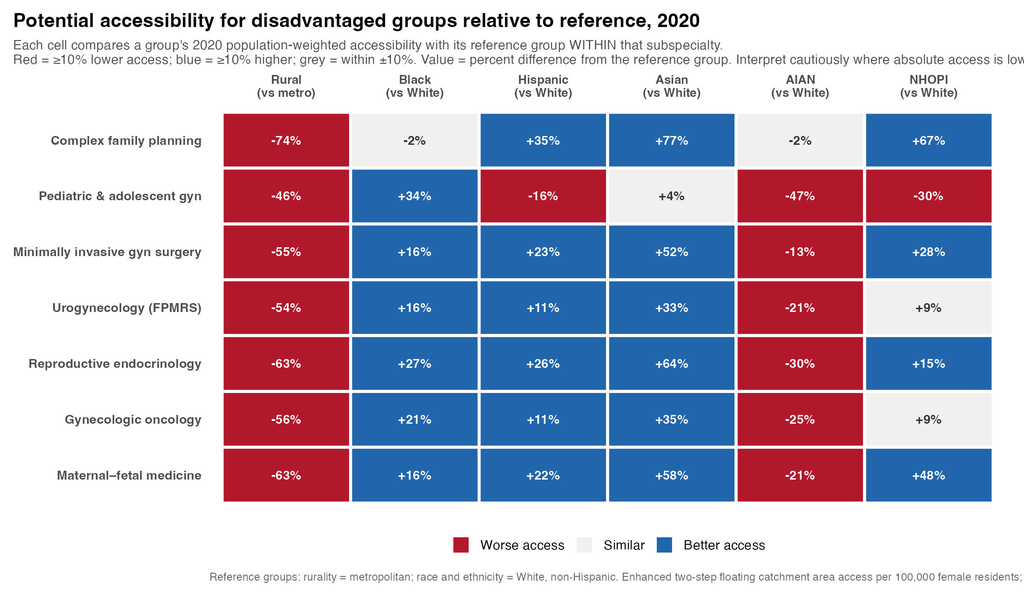

**Figure 4.** Potential accessibility for lower-access strata relative to their reference strata in 2020, across all seven specialty groups. Each cell is the percent difference in 2020 population-weighted accessibility between a stratum and its reference stratum *within* that subspecialty: red = at least 10% lower access, blue = at least 10% higher, gray = within ±10%. Reference groups: rurality, metropolitan; race and ethnicity, non-Hispanic White. Within-subspecialty relative contrasts facilitate comparison across subspecialties of differing scarcity, but should be interpreted cautiously where absolute accessibility is low (for example, complex family planning and pediatric and adolescent gynecology), because relative differences become unstable at very small baseline values. Enhanced two-step floating catchment area access per 100,000 women; tract-level population-weighted; contiguous United States. AIAN, American Indian or Alaska Native; NHOPI, Native Hawaiian or Other Pacific Islander.

## eResults S6: Persistence of disparities over time

Rural and area-level racial disparities persisted across the decade (Figure 5; Appendix Table S1). Over 2013-2022, the metropolitan-to-rural gynecologic oncology accessibility ratio narrowed by 0.008 per year (P=.007; Newey-West P<.001), and the gynecologic oncology zero-access share in areas where American Indian or Alaska Native women lived declined by 0.20 percentage points per year (P<.001; Newey-West P<.001) while remaining highest among race/ethnicity strata in every year. Directions were unchanged under autocorrelation-robust inference, although with only 10 annual estimates the trend tests are imprecise (Appendix Table S1).

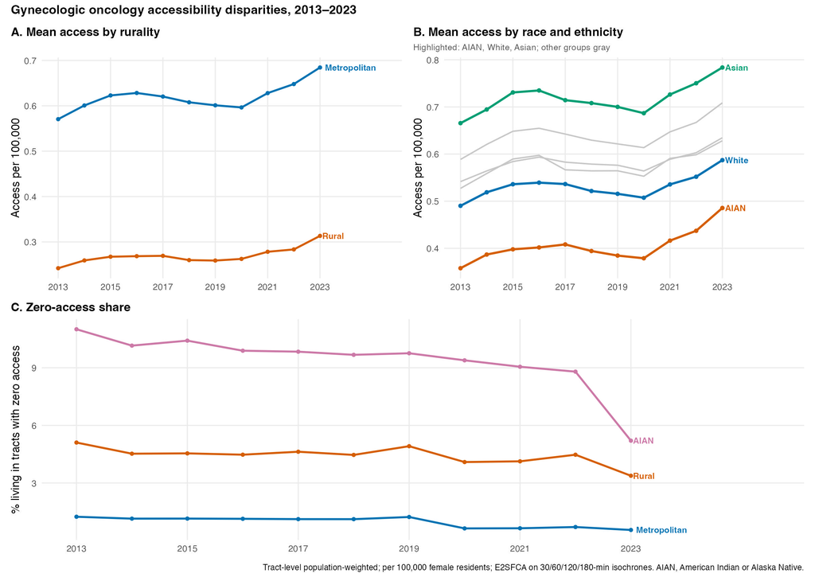

**Figure 5.** Trends in gynecologic oncology potential accessibility disparities, 2013-2023, tract-level population-weighted (per 100,000 women; enhanced two-step floating catchment area on 30/60/120/180-minute isochrones). (A) Mean accessibility by rurality. (B) Mean accessibility by race and ethnicity, with American Indian or Alaska Native (AIAN), non-Hispanic White, and Asian groups highlighted and the remaining groups in gray. (C) Share of each group’s population living in census tracts with zero mean modeled access.

## eResults S7: Access deserts across subspecialties

The magnitude of inaccessibility depended strongly on subspecialty scarcity (Figure 6; Table 3). The rural zero-access share ranged from about 2.5% for MFM to about 34.5% for CFP, and was consistently highest in areas where American Indian or Alaska Native women lived (Table 3). These tract-level, travel-time patterns parallel the county-level, distance-based gynecologic oncology access disparities reported by Desjardins and colleagues [1].

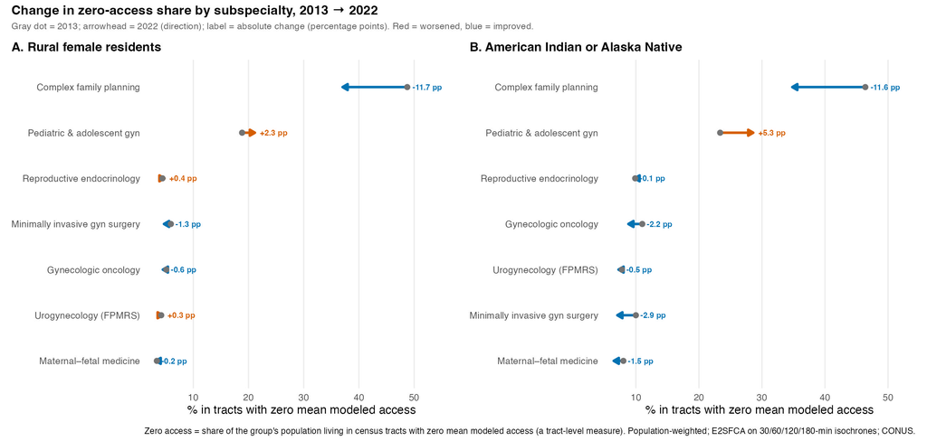

**Figure 6.** Change in the share of (A) rural women and (B) the American Indian or Alaska Native female population living in census tracts with zero mean modeled access, by subspecialty, 2013→2022. The gray dot marks the 2013 value and the arrowhead the 2022 value, so the arrow’s length is the absolute change and its head shows the direction; blue arrows indicate an improvement (falling zero-access share) and red arrows a worsening, with the absolute change (percentage points) labeled. Tract-level population-weighted; enhanced two-step floating catchment area on 30/60/120/180-minute isochrones; contiguous United States.

Table 3. Rural and Racial/Ethnic Disparities in Potential Accessibility, 2020

| Subspecialty | Metro:rural ratio | Rural, % zero | AIAN, access | AIAN, % zero | AIAN − White, % zero |
| --- | --- | --- | --- | --- | --- |
| Gynecologic oncology | 2.27 | 4.09 (4.06-4.12) | 0.379 (0.376-0.382) | 9.39 (9.16-9.60) | 8.18 (7.95-8.39) |
| Maternal-fetal medicine | 2.69 | 2.49 (2.47-2.51) | 0.543 (0.537-0.549) | 6.49 (6.32-6.68) | 5.88 (5.70-6.06) |
| Reproductive endocrinology and infertility | 2.74 | 4.67 (4.64-4.71) | 0.322 (0.318-0.326) | 10.46 (10.22-10.71) | 9.12 (8.88-9.37) |
| Urogynecology and reconstructive pelvic surgery | 2.15 | 4.27 (4.24-4.30) | 0.355 (0.352-0.358) | 7.81 (7.61-8.02) | 6.35 (6.15-6.56) |
| Minimally invasive gynecologic surgery | 2.23 | 7.06 (7.02-7.10) | 0.180 (0.177-0.182) | 14.45 (14.18-14.74) | 11.66 (11.40-11.95) |
| Pediatric and adolescent gynecology | 1.86 | 18.15 (18.09-18.21) | 0.036 (0.035-0.036) | 35.13 (34.69-35.56) | 26.48 (26.04-26.91) |
| Complex family planning | 3.89 | 34.48 (34.41-34.56) | 0.039 (0.038-0.040) | 37.39 (36.95-37.86) | 16.93 (16.49-17.39) |

Values are point estimate (95% ACS uncertainty interval). Access is per 100,000 women. Stratified estimates are tract-level population-weighted (required to attach rurality and race-specific denominators) and reconcile with the cell-level national means (Table 1) to within 0.001. “% zero” is the share of a group’s population living in census tracts with zero mean modeled access. Intervals quantify ACS sampling uncertainty only and are narrower than comprehensive confidence intervals; the metropolitan-to-rural ratio pools over tens of thousands of tracts, so its ACS interval is narrower than the reported precision and it is shown as a point estimate. A deterministic model-specification envelope for the rural:metro and AIAN:White ratios is reported in Appendix Table S2b (Methods). Race-alone and Hispanic-origin groups are not mutually exclusive. AIAN, American Indian or Alaska Native; CFP, complex family planning; GO, gynecologic oncology; MFM, maternal-fetal medicine; MIGS, minimally invasive gynecologic surgery; PAG, pediatric and adolescent gynecology; REI, reproductive endocrinology and infertility; URPS, urogynecology and reconstructive pelvic surgery.

## eResults S8: Change in accessibility by subspecialty

Descriptive changes in potential accessibility from 2013 to 2023 were geographically heterogeneous across subspecialties (Figure 7). This 2013-2023 endpoint comparison, in which 2023 is provisional, is distinct from the 2013-2022 modeled trends reported above. Nationally, population-weighted accessibility increased most for minimally invasive gynecologic surgery (58.5%), and maternal-fetal medicine was the only subspecialty to decline (-19.4%); however, both gains and losses were spatially concentrated rather than uniform across the country. Figure 7 shows the absolute cell-level change, while the facet labels report the national relative change over the same 2013-to-2023 endpoint window (not the primary 2013-to-2022 values reported in Table 1).

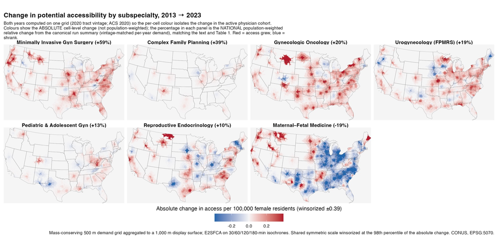

**Figure 7.** Change in potential accessibility by subspecialty, 2013 → 2023. This figure combines two distinct quantities: the map **colors** show the absolute cell-level change in access (per 100,000 women; *not* population-weighted), computed with both years on a common 2020 grid so the spatial pattern isolates the change in the active physician cohort, whereas the **percentage in each panel** is the national population-weighted *relative* change over the full 2013→2023 endpoint. Because 2023 is provisional, this endpoint differs from the 2013-2022 primary period reported in Table 1, and the panel percentages should not be read against Table 1. Red indicates access grew, blue that it shrank. Mass-conserving 500-m demand grid aggregated to a 1,000-m display surface; the shared symmetric color scale is winsorized at ±0.39 per 100,000 women (the 98th percentile of the absolute cell-level change), which clipped 0.7% of cells.

## Reproducibility record (supplement, not part of the typeset manuscript)

*The following provenance metadata is provided for the reproducibility repository and peer review; it is not intended for the submitted/typeset article.*

- **Run:** `e2sfca_20260712_190734` (git `ff3aac4a`)
- **Allocator:** mass_conserving / `allocate_pop_areaweighted` (mode area; module sha256 `2b78718bf65c2ecb`)
- **Headline source:** e2sfca_national_summary.csv (cell-level population-weighted)
- **Cells:** 77 specialty-year national rows (7 specialties × 11 years)

*All scientific values above are inline R expressions evaluated from the canonical run objects at render time; none are hardcoded in prose.*

**Figure provenance.** Every figure was generated in the upstream isochrones pipeline from the frozen run `e2sfca_20260712_190734` and staged into this repository; the generator script, data input, and build date for each are recorded in `docs/FIGURE_PROVENANCE.md` (machine-readable `manuscript/figures/FIGURE_PROVENANCE.csv`) and in a comment above each figure’s chunk. Figure 1 (`fig0_level2020.jpg`) was regenerated 2026-08-02 to remove the in-image title, subtitle, and footnote caption. Filenames do not track figure numbers (for example Figure 5 is `fig4_gotrends.jpg`); resolve by the provenance table.

# References

[1]

Desjardins MR, Desravines N, Fader AN, Wethington SL, Curriero FC. Geographic disparities in potential accessibility to OBGYN subspecialists in the United States from 2001 to 2020. Obstet Gynecol. 2023;142(3):688-97.

[2]

Harris JA, Menke MN, Haefner JK, Moniz MH, Perumalswami CR. Geographic access to assisted reproductive technology health care in the united states: A population-based cross-sectional study. Fertility and Sterility. 2017;107(4):1023-7. https://doi.org/10.1016/j.fertnstert.2017.02.101.

[3]

Akapo OO, Schultz C, Coelho D, Muffly TM. American indian and alaskan native access to obstetrics and gynecology subspecialists: Findings from a national mystery caller study in the united states. Cureus. 2023;15(12):e51403. https://doi.org/10.7759/cureus.51403.

[4]

Penchansky R, Thomas JW. The concept of access: Definition and relationship to consumer satisfaction. Medical Care. 1981;19(2):127-40. https://doi.org/10.1097/00005650-198102000-00001.

[5]

McLaughlin CG, Wyszewianski L. Access to care: Remembering old lessons. Health Services Research. 2002;37(6):1441-3. https://doi.org/10.1111/1475-6773.12171.

[6]

Deng S, Chen Y, Bennett KJ. The association of travel burden with prenatal care utilization: What happens after provider selection. BMC Health Services Research. 2024;24:781. https://doi.org/10.1186/s12913-024-11249-9.

[7]

Pleasants EA, Cartwright AF, Upadhyay UD. Association between distance to an abortion facility and abortion or pregnancy outcome among a prospective cohort of people seeking abortion online. JAMA Network Open. 2022;5(5):e2212065. https://doi.org/10.1001/jamanetworkopen.2022.12065.

[8]

Ambroggi M, Biasini C, Del Giovane C, Fornari F, Cavanna L. Distance as a barrier to cancer diagnosis and treatment: Review of the literature. The Oncologist. 2015;20(12):1378-85. https://doi.org/10.1634/theoncologist.2015-0110.

[9]

Syed ST, Gerber BS, Sharp LK. Traveling towards disease: Transportation barriers to health care access. Journal of Community Health. 2013;38(5):976-93. https://doi.org/10.1007/s10900-013-9681-1.

[10]

Ackroyd SA, Shih Y-CT, Kim B, Lee NK, Halpern MT. A look at the gynecologic oncologist workforce - are we meeting patient demand? Gynecologic Oncology. 2021;163(2):229-36. https://doi.org/10.1016/j.ygyno.2021.08.013.

[11]

Chen V, Ying X, Majdinasab E, Theiler R. Geographic disparities in obstetric care access in the United States. Obstetrics & Gynecology. 2026;147(3):422-4. https://doi.org/10.1097/AOG.0000000000006069.

[12]

Schmidt EM, Ward L, Gregory WT, Cichowski SB. Geographic access to urogynecology care in the united states. Urogynecology. 2024;30(10):829-37. https://doi.org/10.1097/SPV.0000000000001547.

[13]

U.S. Census Bureau. American community survey (ACS) 5-year estimates [Internet]. Suitland (MD): U.S. Census Bureau; 2021. [cited 2026 Feb 28]. Available from: https://www.census.gov/programs-surveys/acs.

[14]

Walker K. Tidycensus: Load US census boundary and attribute data as tidyverse and sf-ready data frames [Internet]. Comprehensive R Archive Network; 2024. [cited 2026 Feb 28]. Available from: https://walker-data.com/tidycensus/.

[15]

Pebesma E. Simple features for R: Standardized support for spatial vector data. R J. 2018;10(1):439-46. Available from: https://journal.r-project.org/archive/2018/RJ-2018-009/.

[16]

U.S. Department of Agriculture, Economic Research Service. Rural-urban commuting area codes. USDA Economic Research Service; 2020.

[17]

Mapzen/Linux Foundation. Valhalla routing engine, version 3.4 [Internet]. San Francisco (CA): Linux Foundation; 2023. [cited 2026 Feb 28]. Available from: https://github.com/valhalla/valhalla.

[18]

Luo W, Qi Y. An enhanced two-step floating catchment area (E2SFCA) method for measuring spatial accessibility to primary care physicians. Health & Place. 2009;15(4):1100-7. https://doi.org/10.1016/j.healthplace.2009.06.002.

[19]

Luo W, Wang F. Measures of spatial accessibility to health care in a GIS environment: Synthesis and a case study in the Chicago region. Environment and Planning B: Planning and Design. 2003;30(6):865-84. https://doi.org/10.1068/b29120.

[20]

Wan N, Zhan FB, Zou B, Chow E. A relative spatial access assessment approach for analyzing potential spatial access to colorectal cancer services in texas. Applied Geography. 2012;32(2):291-9. https://doi.org/10.1016/j.apgeog.2011.05.001.

[21]

Graham S, Hallisey E, Wilt G, Flanagan B, Rodriguez JL, Peipins L. Sociodemographic disparities in access to ovarian cancer treatment. Annals of Cancer Epidemiology. 2019;3:3. https://doi.org/10.21037/ace.2019.10.02.

[22]

Herb J, Shell M, Carlson R, Stitzenberg K. Is long travel distance a barrier to surgical cancer care in the United States? A systematic review. Am J Surg. 2021;222(2):305-10. https://doi.org/10.1016/j.amjsurg.2020.12.005.

[23]

Beroukhim G, Seifer DB. Racial and ethnic disparities in access to and outcomes of infertility treatment and assisted reproductive technology in the United States. Endocrinology and Metabolism Clinics of North America. 2023;52(4):659-75. https://doi.org/10.1016/j.ecl.2023.05.005.

[24]

Peipert BJ, Potapragada NR, Lantos PM, Harris BS, Reinecke J, Goldman KN. A geospatial analysis of disparities in access to oncofertility services. JAMA Oncology. 2023;9(10):1364-70. https://doi.org/10.1001/jamaoncol.2023.2780.

[25]

Seifer DB, Sharara FI, Jain T. The disparities in ART (DART) hypothesis of racial and ethnic disparities in access and outcomes of IVF treatment in the USA. Reproductive Sciences. 2022;29(7):2084-8. https://doi.org/10.1007/s43032-022-00888-0.

[26]

Ebinger JE, Lan R, Driver MP, Rushworth P, Luong E, Sun N, et al. Disparities in geographic access to cardiac rehabilitation in Los Angeles county. Journal of the American Heart Association. 2022;11(15):e026472. https://doi.org/10.1161/JAHA.121.026472.

[27]

Yilma M, Dalal N, Wadhwani SI, Hirose R, Mehta N. Geographic disparities in access to liver transplantation. Liver Transplantation. 2023;29(9):987-97. https://doi.org/10.1097/LVT.0000000000000182.

[28]

Liu X, Fluchel MN, Kirchhoff AC, Zhu H, Onega T. Geographic access to pediatric cancer care in the US. JAMA Network Open. 2023;6(1):e2251524. https://doi.org/10.1001/jamanetworkopen.2022.51524.

[29]

Towne SD, Smith ML, Ory MG. Geographic variations in access and utilization of cancer screening services: Examining disparities among American Indian and Alaska Native elders. International Journal of Health Geographics. 2014;13:18. https://doi.org/10.1186/1476-072X-13-18.

[30]

El Khoury CJ. Application of geographic information systems (GIS) in the study of prostate cancer disparities: A systematic review. Cancers. 2024;16(15):2715. https://doi.org/10.3390/cancers16152715.

[31]

Hecox EE, Boydstun AG, Talbot HG, Edwards SR, Anderson L, Benedict KC, et al. Geographic disparities in access to certified hand therapists in the United States. Journal of Hand Surgery (American Volume). 2026;51(3):322.e1-8. https://doi.org/10.1016/j.jhsa.2025.05.013.

[32]

Welch AC, Gorden JA, Mooney SJ, Wilshire CL, Zeliadt SB. Understanding Washington state’s low uptake of lung cancer screening in two steps: A geospatial analysis of patient travel time and health care availability of imaging sites. Chest. 2024;166(3):622-31. https://doi.org/10.1016/j.chest.2024.04.021.

[33]

Campbell JE, Sambo AB, St. James N, Willingham K, Warren H, Penaflor J, et al. Spatial accessibility for deploying mobile lung cancer screenings in a rural state using two-step floating catchment spatial analysis in Oklahoma, United States. Preventive Medicine Reports. 2025;60:103290. https://doi.org/10.1016/j.pmedr.2025.103290.

[34]

Charlesworth CJ, Nagy D, Drake C, Manibusan B, Zhu JM. Rural and frontier access to mental health prescribers and nonprescribers: A geospatial analysis in Oregon Medicaid. The Journal of Rural Health. 2024;40(1):16-25. https://doi.org/10.1111/jrh.12761.

[35]

Rahman MS, Martinez A, Elani HW. Geographic access to dental specialists in the United States. Journal of Dental Research. 2026;105(7):875-82. https://doi.org/10.1177/00220345251388919.

[36]

Arora S, Brakey HR, Jones JL, Hood N, Fuentes JE, Cirolia L. Project ECHO for cancer care: A scoping review of provider outcome evaluations. Journal of Cancer Education. 2023. https://doi.org/10.1007/s13187-023-02292-x.

[37]

Bassett MT, Galea S. Reparations as a public health priority - a strategy for ending Black-White health disparities. New England Journal of Medicine. 2020;383(22):2101-3. https://doi.org/10.1056/NEJMp2026170.

[38]

McCrum ML, Wan N, Han J, Lizotte SL, Horns JJ. Disparities in spatial access to emergency surgical services in the US. JAMA Health Forum. 2022;3(10):e223633. https://doi.org/10.1001/jamahealthforum.2022.3633.

[39]

Campbell JE, Janitz A, Sambo AB, St. James N, Pharr SF, Doescher MP. Optimizing mobile mammography deployment in Oklahoma 2024: A two-step floating catchment area approach. Geospatial Health. 2026;21(1). https://doi.org/10.4081/gh.2026.1426.

[40]

Greenberg AL, Brand NR, Zambeli-Ljepović A, Barnes KE, Chiou SH, Rhoads KF, et al. Exploring the complexity and spectrum of racial/ethnic disparities in colon cancer management. International Journal for Equity in Health. 2023;22(1):68. https://doi.org/10.1186/s12939-023-01883-w.

[41]

Hod T, Goldfarb-Rumyantzev AS. The role of disparities and socioeconomic factors in access to kidney transplantation and its outcome. Renal Failure. 2014;36(8):1193-9. https://doi.org/10.3109/0886022X.2014.934179.

[42]

Apparicio P, Gelb J, Dube A-S, Kingham S, Gauvin L, Robitaille E. The approaches to measuring the potential spatial access to urban health services revisited: Distance types and aggregation-error issues. International Journal of Health Geographics. 2017;16:32. https://doi.org/10.1186/s12942-017-0105-9.

[43]

Drake C, Cai C, Anderson D, Sabik LM. A comparison of methods for measuring spatial access to health care. Health Services Research. 2021;56(5):777-87. https://doi.org/10.1111/1475-6773.13700.

[44]

Bryant J, Delamater PL. Examination of spatial accessibility at micro- and macro-levels using the enhanced two-step floating catchment area (E2SFCA) method. Annals of GIS. 2019;25(3):219-29. https://doi.org/10.1080/19475683.2019.1641553.

[45]

Vadrevu L, Kanjilal B. Measuring spatial equity and access to maternal health services using enhanced two step floating catchment area method (E2SFCA): A case study of the Indian Sundarbans. International Journal for Equity in Health. 2016;15:87. https://doi.org/10.1186/s12939-016-0376-y.

[46]

Gilliland JA, Shah TI, Clark A, Sibbald S, Seabrook JA. A geospatial approach to understanding inequalities in accessibility to primary care among vulnerable populations. PLoS ONE. 2019;14(1):e0210113. https://doi.org/10.1371/journal.pone.0210113.

[47]

Wurdeman T, Torres Balarezo A, Borrero Vega A, Dey T, Falconi M, Garcia MJ, et al. Access to surgery in Ecuador using the enhanced 2-step floating catchment area approach. BMC Global and Public Health. 2026;4:14. https://doi.org/10.1186/s44263-026-00241-6.

[48]

Utaka EN, Yang X, Xia H, Wang S, Shi F, Li Q, et al. Geospatial accessibility factors influencing HIV care continuum outcomes in South Carolina. AIDS and Behavior. 2026. https://doi.org/10.1007/s10461-026-05161-y.

[49]

Petzold T, Nauck F, Banse C, Augustin J, Jansky M. Spatial access to palliative care units in Germany: Integrated analysis of availability and accessibility using the E2SFCA method. Bundesgesundheitsblatt Gesundheitsforschung Gesundheitsschutz. 2025;68(10):1128-37. https://doi.org/10.1007/s00103-025-04124-3.

[50]

Arora A, Kulkarni A, Srinivasa S. GeoHealth Karnataka: A geospatial framework for comprehensive healthcare accessibility analysis. Proceedings of the 19th international symposium on spatial and temporal data (SSTD ’25), ACM; 2025, p. 238-42. https://doi.org/10.1145/3748777.3748798.

[51]

Stacherl B, Sauzet O. Gravity models for potential spatial healthcare access measurement: A systematic methodological review. International Journal of Health Geographics. 2023;22:34. https://doi.org/10.1186/s12942-023-00358-z.

[52]

Nakamura T, Nakamura A, Mukuda K, Harada M, Kotani K. Potential accessibility scores for hospital care in a province of Japan: GIS-based ecological study of the two-step floating catchment area method and the number of neighborhood hospitals. BMC Health Services Research. 2017;17:438. https://doi.org/10.1186/s12913-017-2367-0.

[53]

Sánchez-Cárdenas MA, León MX, Rodríguez-Campos LF, Vargas-Escobar LM, Cabezas L, Tamayo-Díaz JP, et al. Accessibility to palliative care services in Colombia: An analysis of geographic disparities. BMC Public Health. 2024;24:1659. https://doi.org/10.1186/s12889-024-19132-2.

[54]

Liu X, Patel AB, Seidel JE, Mosher DP, Hagens J, Marshall DA. Geographic disparities in access to primary and rheumatology care: Potential versus realized access. Canadian Geographies / Géographies Canadiennes. 2026;70(1):e70063. https://doi.org/10.1111/cag.70063.

[55]

Hong I, Wilson B, Gross T, Conley J, Powers T. Challenging terrains: Socio-spatial analysis of primary health care access disparities in West Virginia. Applied Spatial Analysis and Policy. 2023;16(1):141-61. https://doi.org/10.1007/s12061-022-09472-0.

[56]

Weng Y-X, Hsieh C-C, Liao H-C, Tung Y-C. Impact of spatial accessibility to primary care physicians on health care outcomes and costs. International Journal of Health Geographics. 2025;24:38. https://doi.org/10.1186/s12942-025-00430-w.

[57]

McGrail MR. Spatial accessibility of primary health care utilising the two-step floating catchment area method: An assessment of recent improvements. International Journal of Health Geographics. 2012;11:50. https://doi.org/10.1186/1476-072X-11-50.

[58]

McGrail MR, Humphreys JS. Measuring spatial accessibility to primary care in rural areas: Improving the effectiveness of the two-step floating catchment area method. Applied Geography. 2009;29(4):533-41. https://doi.org/10.1016/j.apgeog.2008.12.003.

[59]

Delamater PL. Spatial accessibility in suboptimally configured health care systems: A modified two-step floating catchment area (M2SFCA) metric. Health & Place. 2013;24:30-43. https://doi.org/10.1016/j.healthplace.2013.07.012.

[60]

Zhang S, Wang F, Shi X. Trap of weights: The reuse of weights in the floating catchment area (FCA) methods to measuring accessibility. International Journal of Health Geographics. 2023;22:8. https://doi.org/10.1186/s12942-023-00330-x.

[61]

Luo J. Variable catchment sizes for the two-step floating catchment area (2SFCA) method. Health & Place. 2012;18(4):789-95. https://doi.org/10.1016/j.healthplace.2012.04.009.

[62]

Shao Y, Luo W. Supply-demand adjusted two-steps floating catchment area (SDA-2SFCA) model for measuring spatial access to health care. Social Science & Medicine. 2022;296:114727. https://doi.org/10.1016/j.socscimed.2022.114727.

[63]

Khosravi Kazazi A, Li Z. Bridging theory and behavior for healthcare accessibility modeling: A mobility-driven revision of the E2SFCA. PLOS ONE. 2026;21(4):e0346009. https://doi.org/10.1371/journal.pone.0346009.

[64]

Li H, Wang F, Zhang R, Qin A, Javan E, Reddy R, et al. Measuring maternal healthcare accessibility in florida by a data-driven extension of V2SFCA. Health & Place. 2026;98:103608. https://doi.org/10.1016/j.healthplace.2026.103608.

[65]

Park J, Goldberg DW. An examination of the stochastic distribution of spatial accessibility to intensive care unit beds during the COVID-19 pandemic. ISPRS International Journal of Geo-Information. 2022;12(8):326. https://doi.org/10.3390/ijgi11080326.

[66]

Gao F, Kihal W, Le Meur N, Souris M, Deguen S. Does the edge effect impact on the measure of spatial accessibility to healthcare providers? International Journal of Health Geographics. 2017;16:46. https://doi.org/10.1186/s12942-017-0119-3.

[^1]: Because subspecialty is ascertained from ABOG certification, the urogynecology and reconstructive pelvic surgery (URPS) cohort counts only physicians certified through the ABOG pathway; physicians who entered urogynecology through the American Board of Urology (ABU) pathway are not captured. The 2020 URPS supply in Table 1 is therefore a single-year, ABOG-only count. For 2023, the board-certified active urogynecology workforce comprises 1,027 physicians through the ABOG pathway and 279 ABU net-new physicians (1,306 nationally and 1,303 in the contiguous United States); the difference from the 2020 figure reflects the later measure year and the added ABU pathway rather than a difference in ascertainment.